# Project 2

Michelle Mondy

October 7, 2017

# Load the required packages

```r
library(RCurl)
library(tidyr)
library(dplyr)
```

# Load the csv file

I created a CSV file from Sedo Oh’s discussion board post example. Table 1, which shows the Pre-foreclosure notices issued to 1-4 unit properties from 2011-2016.

You can find an image of this table on my github repo here: https://github.com/mmondy/MSDS/blob/master/DATA607/Week%206/Pre-foreclosure%20notices%20document%20image.PNG

```r
foreclosure_notices <- data.frame(read.csv(text = getURL("https://raw.githubusercontent.com/mmondy/MSDS/master/DATA607/Week%206/Pre-foreclosure%20notices%20nyc%20data.csv"), header = T))
View(foreclosure_notices)
```

# Transform the data into a tidy format

In order to do this, we need to use the tidyr and dplyr packages to put the data in a more usable format. Since the last column shows the percentage change from 2015-2016 we need to drop this column as it will not be accurate once the data is transformed. We also should note, the 6th row shows NYC overall.

```r
tidy_foreclosures <-  select(foreclosure_notices, -starts_with("Pct_Chg")) %>% gather("Year", "Notices", 2:7)
head(tidy_foreclosures)
```

```
##     Borough  Year Notices
## 1     Bronx X2011    8770
## 2  Brooklyn X2011   21351
## 3 Manhattan X2011    1142
## 4   Queens  X2011   29307
## 5 S. Island X2011   10319
## 6       NYC X2011   70889
```

# Analysis

The analysis requested was to see line graphs of the number of notices for each borough by year. Additionally, NYC overall is plotted on the below line graph.

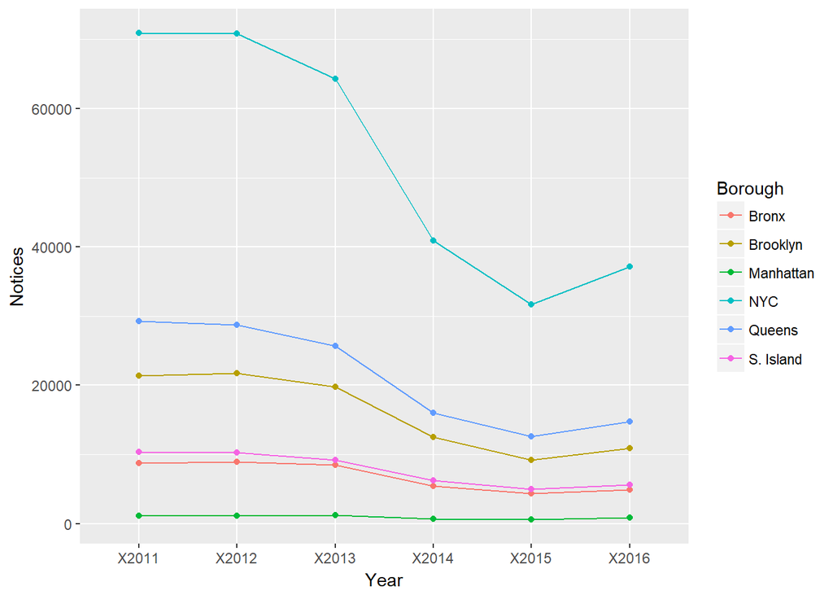

```r
library(ggplot2)

ggplot(data=tidy_foreclosures, aes(x=Year, y=Notices, group=Borough, colour=Borough)) +
    geom_line() +
    geom_point()
```

# Additional question

How many notices were issues by borough overall from 2011 - 2016? Again, NYC represents the sum of all Boroughs.

```r
Total_Notices <- tidy_foreclosures %>% group_by(Borough) %>% summarise(total_notices=sum(Notices))
Total_Notices %>%  arrange(desc(total_notices))
```

```
## # A tibble: 6 x 2
##     Borough total_notices
##      <fctr>         <int>
## 1       NYC        315789
## 2   Queens         127106
## 3  Brooklyn         95456
## 4 S. Island         46607
## 5     Bronx         40869
## 6 Manhattan          5751
```

# Conclusions

As also noted in the document, there was an increase in pre-foreclosure notices from 2015 to 2016. However, it is still well below 2011. From the graph above, it looks like Queens and Brooklyn may have contributed the most to this increase. Queens and Brooklyn also have the most notices overall between 2011 and 2016.